```python
import pandas as pd
import seaborn as sns
import matplotlib.pyplot as plt
import numpy as np
from datetime import datetime, date
import warnings
warnings.filterwarnings('ignore')
pd.set_option('display.max_column', 162)
pd.set_option('display.max_row', 162)
```

# Contexte

L'agence **Santé publique France** a lancé un appel à projets pour trouver des idées innovantes d’applications en lien avec l'alimentation. Vous souhaitez y participer et proposer une idée d’application.

# Partie 1 - Objectif

- Trouver une idée d’application : sélection des variables pertinentes
- Traitement des données ( imputation, gestion des valeurs aberrantes / manquantes)
- Automatisant des traitements.
- Tests hypothèses et analyses exploratoires
- Identifier des arguments justifiant la faisabilité (ou non) de l’application à partir des données Open Food Facts.
- Rédiger un rapport d’exploration et pitcher votre idée durant la soutenance du projet.

Chargez le fichier `fr.openfoodfacts.org.products.csv` à l'aide de Pandas. Stockez le résultat du chargement dans la variable `df`.

```python
df = pd.read_csv('fr.openfoodfacts.org.products.csv', sep='\t')
```

# Les données Open Food Facts

Open Food Facts est un projet collaboratif dont le but est de constituer une base de données libre et ouverte sur les produits alimentaires commercialisés dans le monde entier

[figure not shown]

## Compréhension des données

Chargement du fichiers csv avec la fonction read_csv de Pandas  
Utilisation des fonctions **head(),shape et describe()**

Head() pour afficher les 5 premières lignes du dataframe `df`.

```python
df.head()
```

|  | code | url | creator | created_t | created_datetime | last_modified_t | last_modified_datetime | product_name | generic_name | quantity | packaging | packaging_tags | brands | brands_tags | categories | categories_tags | categories_fr | origins | origins_tags | manufacturing_places | manufacturing_places_tags | labels | labels_tags | labels_fr | emb_codes | emb_codes_tags | first_packaging_code_geo | cities | cities_tags | … |
| --- | --- | --- | --- | --- | --- | --- | --- | --- | --- | --- | --- | --- | --- | --- | --- | --- | --- | --- | --- | --- | --- | --- | --- | --- | --- | --- | --- | --- | --- | --- |
| 0 | 3087 | http://world-fr.openfoodfacts.org/produit/0000... | openfoodfacts-contributors | 1474103866 | 2016-09-17T09:17:46Z | 1474103893 | 2016-09-17T09:18:13Z | Farine de blé noir | NaN | 1kg | NaN | NaN | Ferme t'y R'nao | ferme-t-y-r-nao | NaN | NaN | NaN | NaN | NaN | NaN | NaN | NaN | NaN | NaN | NaN | NaN | NaN | NaN | NaN | … |
| 1 | 4530 | http://world-fr.openfoodfacts.org/produit/0000... | usda-ndb-import | 1489069957 | 2017-03-09T14:32:37Z | 1489069957 | 2017-03-09T14:32:37Z | Banana Chips Sweetened (Whole) | NaN | NaN | NaN | NaN | NaN | NaN | NaN | NaN | NaN | NaN | NaN | NaN | NaN | NaN | NaN | NaN | NaN | NaN | NaN | NaN | NaN | … |
| 2 | 4559 | http://world-fr.openfoodfacts.org/produit/0000... | usda-ndb-import | 1489069957 | 2017-03-09T14:32:37Z | 1489069957 | 2017-03-09T14:32:37Z | Peanuts | NaN | NaN | NaN | NaN | Torn & Glasser | torn-glasser | NaN | NaN | NaN | NaN | NaN | NaN | NaN | NaN | NaN | NaN | NaN | NaN | NaN | NaN | NaN | … |
| 3 | 16087 | http://world-fr.openfoodfacts.org/produit/0000... | usda-ndb-import | 1489055731 | 2017-03-09T10:35:31Z | 1489055731 | 2017-03-09T10:35:31Z | Organic Salted Nut Mix | NaN | NaN | NaN | NaN | Grizzlies | grizzlies | NaN | NaN | NaN | NaN | NaN | NaN | NaN | NaN | NaN | NaN | NaN | NaN | NaN | NaN | NaN | … |
| 4 | 16094 | http://world-fr.openfoodfacts.org/produit/0000... | usda-ndb-import | 1489055653 | 2017-03-09T10:34:13Z | 1489055653 | 2017-03-09T10:34:13Z | Organic Polenta | NaN | NaN | NaN | NaN | Bob's Red Mill | bob-s-red-mill | NaN | NaN | NaN | NaN | NaN | NaN | NaN | NaN | NaN | NaN | NaN | NaN | NaN | NaN | NaN | … |

la taille du dataframe avec shape

```python
df.shape
```

```
(320772, 162)
```

min, max, moyenne, écart type, etc) pour toutes les variables quantitatives avec describes

```python
df.describe()
```

|  | no_nutriments | additives_n | ingredients_from_palm_oil_n | ingredients_from_palm_oil | ingredients_that_may_be_from_palm_oil_n | ingredients_that_may_be_from_palm_oil | nutrition_grade_uk | energy_100g | energy-from-fat_100g | fat_100g | saturated-fat_100g | butyric-acid_100g | caproic-acid_100g | caprylic-acid_100g | capric-acid_100g | lauric-acid_100g | myristic-acid_100g | palmitic-acid_100g | stearic-acid_100g | arachidic-acid_100g | behenic-acid_100g | lignoceric-acid_100g | cerotic-acid_100g | montanic-acid_100g | melissic-acid_100g | monounsaturated-fat_100g | polyunsaturated-fat_100g | omega-3-fat_100g | alpha-linolenic-acid_100g | … |
| --- | --- | --- | --- | --- | --- | --- | --- | --- | --- | --- | --- | --- | --- | --- | --- | --- | --- | --- | --- | --- | --- | --- | --- | --- | --- | --- | --- | --- | --- | --- |
| count | 0.0 | 248939.000000 | 248939.000000 | 0.0 | 248939.000000 | 0.0 | 0.0 | 2.611130e+05 | 857.000000 | 243891.000000 | 229554.000000 | 0.0 | 0.0 | 1.0 | 2.000000 | 4.000000 | 1.0 | 1.0 | 1.0 | 24.000000 | 23.000000 | 0.0 | 0.0 | 1.0 | 0.0 | 22823.000000 | 22859.000000 | 841.000000 | 186.000000 | … |
| mean | NaN | 1.936024 | 0.019659 | NaN | 0.055246 | NaN | NaN | 1.141915e+03 | 585.501214 | 12.730379 | 5.129932 | NaN | NaN | 7.4 | 6.040000 | 36.136182 | 18.9 | 8.1 | 3.0 | 10.752667 | 10.673913 | NaN | NaN | 61.0 | NaN | 10.425055 | 6.312493 | 3.182103 | 2.250285 | … |
| std | NaN | 2.502019 | 0.140524 | NaN | 0.269207 | NaN | NaN | 6.447154e+03 | 712.809943 | 17.578747 | 8.014238 | NaN | NaN | NaN | 0.226274 | 24.101433 | NaN | NaN | NaN | 4.019993 | 3.379647 | NaN | NaN | NaN | NaN | 17.076167 | 10.832591 | 5.607988 | 7.971418 | … |
| min | NaN | 0.000000 | 0.000000 | NaN | 0.000000 | NaN | NaN | 0.000000e+00 | 0.000000 | 0.000000 | 0.000000 | NaN | NaN | 7.4 | 5.880000 | 0.044730 | 18.9 | 8.1 | 3.0 | 0.064000 | 5.200000 | NaN | NaN | 61.0 | NaN | 0.000000 | 0.000000 | 0.000000 | 0.000000 | … |
| 25% | NaN | 0.000000 | 0.000000 | NaN | 0.000000 | NaN | NaN | 3.770000e+02 | 49.400000 | 0.000000 | 0.000000 | NaN | NaN | 7.4 | 5.960000 | 34.661183 | 18.9 | 8.1 | 3.0 | 7.275000 | 7.100000 | NaN | NaN | 61.0 | NaN | 0.000000 | 0.000000 | 0.600000 | 0.068750 | … |
| 50% | NaN | 1.000000 | 0.000000 | NaN | 0.000000 | NaN | NaN | 1.100000e+03 | 300.000000 | 5.000000 | 1.790000 | NaN | NaN | 7.4 | 6.040000 | 47.600000 | 18.9 | 8.1 | 3.0 | 12.850000 | 12.600000 | NaN | NaN | 61.0 | NaN | 4.000000 | 2.220000 | 1.800000 | 0.117500 | … |
| 75% | NaN | 3.000000 | 0.000000 | NaN | 0.000000 | NaN | NaN | 1.674000e+03 | 898.000000 | 20.000000 | 7.140000 | NaN | NaN | 7.4 | 6.120000 | 49.075000 | 18.9 | 8.1 | 3.0 | 13.375000 | 13.050000 | NaN | NaN | 61.0 | NaN | 10.710000 | 7.140000 | 3.200000 | 0.604000 | … |
| max | NaN | 31.000000 | 2.000000 | NaN | 6.000000 | NaN | NaN | 3.251373e+06 | 3830.000000 | 714.290000 | 550.000000 | NaN | NaN | 7.4 | 6.200000 | 49.300000 | 18.9 | 8.1 | 3.0 | 15.400000 | 14.600000 | NaN | NaN | 61.0 | NaN | 557.140000 | 98.000000 | 60.000000 | 75.000000 | … |

```python
df.columns
```

```
Index(['code', 'url', 'creator', 'created_t', 'created_datetime',
       'last_modified_t', 'last_modified_datetime', 'product_name',
       'generic_name', 'quantity',
       ...
       'ph_100g', 'fruits-vegetables-nuts_100g',
       'collagen-meat-protein-ratio_100g', 'cocoa_100g', 'chlorophyl_100g',
       'carbon-footprint_100g', 'nutrition-score-fr_100g',
       'nutrition-score-uk_100g', 'glycemic-index_100g',
       'water-hardness_100g'],
      dtype='object', length=162)
```

```python
for col in df.columns:
    print(col,df[col].nunique())
```

```
code 320638
url 320749
creator 3535
created_t 189636
created_datetime 189568
last_modified_t 180639
last_modified_datetime 180495
product_name 221347
generic_name 38584
quantity 13826
packaging 14547
packaging_tags 12064
brands 58784
brands_tags 50253
categories 36982
categories_tags 21142
categories_fr 21152
origins 4840
origins_tags 4372
manufacturing_places 7308
manufacturing_places_tags 6736
labels 18114
labels_tags 13653
labels_fr 13655
emb_codes 8462
emb_codes_tags 8158
first_packaging_code_geo 1602
cities 3
cities_tags 2572
purchase_places 5120
stores 3259
countries 1434
countries_tags 725
countries_fr 722
ingredients_text 205520
allergens 12939
allergens_fr 19
traces 8378
traces_tags 3578
traces_fr 3584
```

[output cut: 107 more lines]

```
chromium_100g 17
molybdenum_100g 9
iodine_100g 111
caffeine_100g 42
taurine_100g 17
ph_100g 25
fruits-vegetables-nuts_100g 333
collagen-meat-protein-ratio_100g 6
cocoa_100g 84
chlorophyl_100g 0
carbon-footprint_100g 202
nutrition-score-fr_100g 55
nutrition-score-uk_100g 55
glycemic-index_100g 0
water-hardness_100g 0
```

# Trouver une idée d’application : sélection des variables pertinentes

Utiliser un algorithme de machine learning afin de determiner le Nutriscore Nous aurons besoin des valeurs nutritionnelles ( terminant par_100g), des produits et la valeurs du nutriscore

## Data Cleaning

On commence par filtrer nos données pour obtenir un dataset avec unquement les features interessantes pour notre application

```python
df = df[['created_datetime',
         'countries',
         'creator',
         'product_name',
         'origins',
         'fat_100g',
         'sugars_100g',
         'energy_100g',
         'carbohydrates_100g',
         'saturated-fat_100g',
         'fiber_100g',
         'proteins_100g',
         'salt_100g',
         'fruits-vegetables-nuts_100g',
         'nutrition-score-fr_100g',
         'pnns_groups_1',
         'nutrition_grade_fr']]
```

```python
#info()
df.info()
```

```
<class 'pandas.core.frame.DataFrame'>
RangeIndex: 320772 entries, 0 to 320771
Data columns (total 17 columns):
 #   Column                       Non-Null Count   Dtype
---  ------                       --------------   -----
 0   created_datetime             320763 non-null  object
 1   countries                    320492 non-null  object
 2   creator                      320770 non-null  object
 3   product_name                 303010 non-null  object
 4   origins                      22190 non-null   object
 5   fat_100g                     243891 non-null  float64
 6   sugars_100g                  244971 non-null  float64
 7   energy_100g                  261113 non-null  float64
 8   carbohydrates_100g           243588 non-null  float64
 9   saturated-fat_100g           229554 non-null  float64
 10  fiber_100g                   200886 non-null  float64
 11  proteins_100g                259922 non-null  float64
 12  salt_100g                    255510 non-null  float64
 13  fruits-vegetables-nuts_100g  3036 non-null    float64
 14  nutrition-score-fr_100g      221210 non-null  float64
 15  pnns_groups_1                91513 non-null   object
 16  nutrition_grade_fr           221210 non-null  object
dtypes: float64(10), object(7)
memory usage: 41.6+ MB
```

## % Missing Values

|  | Total | Percent |
| --- | --- | --- |
| fruits-vegetables-nuts_100g | 317736 | 0.990535 |
| origins | 298582 | 0.930823 |
| pnns_groups_1 | 229259 | 0.714710 |
| fiber_100g | 119886 | 0.373742 |
| nutrition_grade_fr | 99562 | 0.310382 |
| nutrition-score-fr_100g | 99562 | 0.310382 |
| saturated-fat_100g | 91218 | 0.284370 |
| carbohydrates_100g | 77184 | 0.240620 |
| fat_100g | 76881 | 0.239675 |
| sugars_100g | 75801 | 0.236308 |
| salt_100g | 65262 | 0.203453 |
| proteins_100g | 60850 | 0.189699 |
| energy_100g | 59659 | 0.185986 |
| product_name | 17762 | 0.055373 |
| countries | 280 | 0.000873 |
| created_datetime | 9 | 0.000028 |
| creator | 2 | 0.000006 |

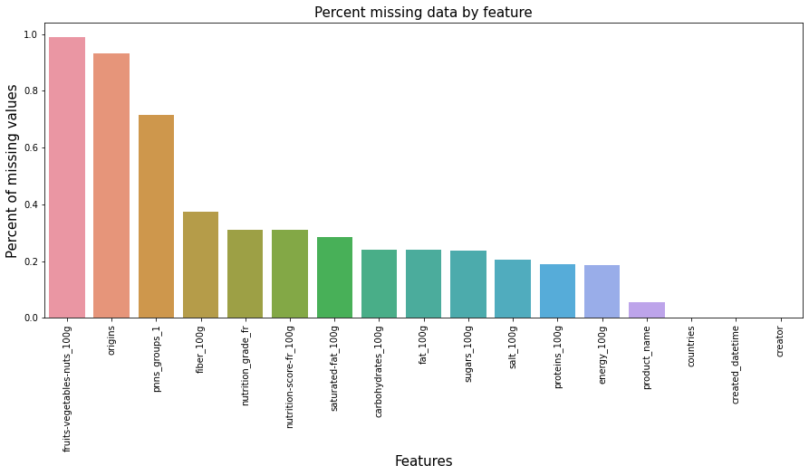

```python
#les total de data pour chaque feature et le pourcentage de missing value
total = df.isnull().sum().sort_values(ascending=False)
percent = (df.isnull().sum()/df.isnull().count()).sort_values(ascending=False)
missing_data = pd.concat([total, percent], axis=1, keys=['Total', 'Percent'])
f, ax = plt.subplots(figsize=(15, 6))
plt.xticks(rotation='90')
sns.barplot(x=missing_data.index, y=missing_data['Percent'])
plt.xlabel('Features', fontsize=15)
plt.ylabel('Percent of missing values', fontsize=15)
plt.title('Percent missing data by feature', fontsize=15)
missing_data
```

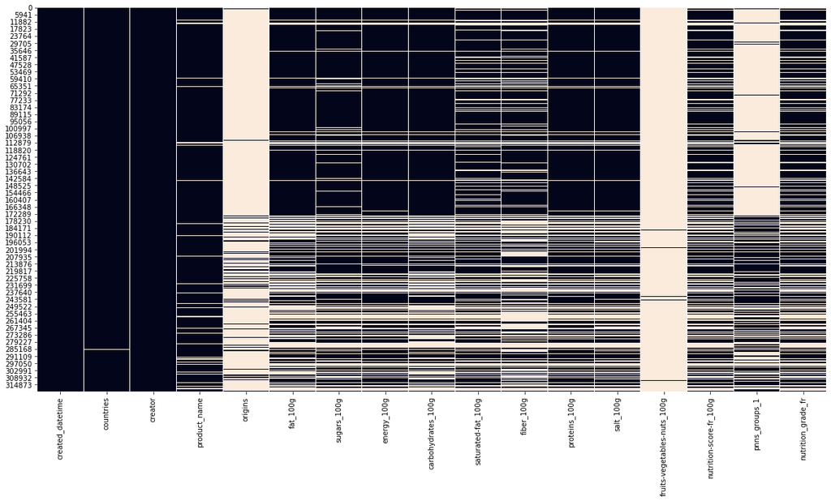

```python
#sisualisation des Nan avec seaborn et le heatmap
plt.figure(figsize=(20,10))
sns.heatmap(df.isna(), cbar=False)
```

Nayant pas suffisament de données, nous décidons de retirer les features origins et fruits et vegetables, Malheureusement car l'information fruits et vegetables était interessante à exploiter pour le calcul du nutriscore.

```python
#création de missing rate
missing_rate = df.isna().sum()/df.shape[0]
```

```python
missing_rate
```

```
created_datetime               0.000028
countries                      0.000873
creator                        0.000006
product_name                   0.055373
origins                        0.930823
fat_100g                       0.239675
sugars_100g                    0.236308
energy_100g                    0.185986
carbohydrates_100g             0.240620
saturated-fat_100g             0.284370
fiber_100g                     0.373742
proteins_100g                  0.189699
salt_100g                      0.203453
fruits-vegetables-nuts_100g    0.990535
nutrition-score-fr_100g        0.310382
pnns_groups_1                  0.714710
nutrition_grade_fr             0.310382
dtype: float64
```

On fixe un seuil de 90% de valeurs manquantes, nous supprimerons les features avec un taux de missing value au delà

```python
df.drop(df.columns[missing_rate>0.9], axis=1, inplace=True)
```

## Countries Column Filtering

Nous utiliserons regex pour conserver uniquement les lignes avec le nom France et FR

```python
import re
```

```python
df['countries'] = df['countries'].astype(str)
```

```python
df['countries'].value_counts().index.tolist()
```

```
['US',
 'France',
 'en:FR',
 'Suisse',
 'Deutschland',
 'España',
 'United Kingdom',
 'United States',
 'en:CH',
 'en:BE',
 'en:GB',
 'Australia',
 'en:DE',
 'Россия',
 'en:ES',
 'Belgique',
 'en:US',
 'en:AU',
 'en:IT',
 'en:CA',
 'France, Suisse',
 'Portugal',
 'Germany',
 'Switzerland',
 'Italia',
 'Canada',
 'nan',
 'Nederland',
 'Belgium',
 'Spain',
 'Belgique,France',
 'en:CZ',
 'France,Suisse',
 'en:FR, Suisse',
 'en:AT',
 'en:TH',
 'en:NL',
 'Österreich',
 'Brasil',
 'Magyarország',
```

[output cut: 946 more lines]

```
 'France,Espagne,Italie,Portugal',
 'France,United Kingdom,United States',
 'Portugal,Espanha,França,Reino Unido,Itália,Alemanha,Roménia,Grécia',
 'Belgium,France,Serbia,Switzerland',
 'France,Royaume-Uni,Pays-Bas',
 'Dänemark,Frankreich,Deutschland, en:switzerland, en:belgium',
 'France, en:switzerland, en:belgium, en:luxembourg',
 'Nederland, en:france',
 'Belgium,Canada,France',
 'UK, Suisse',
 'Colombia,Chile',
 'belgium, en:france',
 'Irak',
 'France,Italy,Spain, Suisse',
 ...]
```

```python
France = re.compile('France')
FR = re.compile('en:FR')
```

```python
df['France'] = df['countries'].str.extract('(France)', expand=True)
df['FR'] = df['countries'].str.extract('(FR)', expand=True)
```

```python
df = df[(df['France'] == 'France') | (df['FR'] == 'FR')]
```

```python
df.drop(['FR','France'], axis=1,inplace=True)
```

## Date Column Filtering

On s'interesse maintenant à la feature Created datetime pour avoir une idée de l'étendue temporelle de nos données

```python
df['created_datetime'] = df['created_datetime'].astype(str)

# Isoler les années avec la fonction split
df["Year"] = df['created_datetime'].apply(
    lambda x: x.split('-')[0])
```

```python
# verification des date unique
df["Year"].nunique()
```

```
7
```

```python
# nombre de dates
df["Year"].value_counts()
```

```
2016    30760
2017    23529
2015    22759
2014     9027
2013     8309
2012     3163
nan         1
Name: Year, dtype: int64
```

On remarque une 'année' correspondant à Nan. Nous eliminons cette ligne de notre dataframe

```python
df[df["Year"]=='nan']
```

|  | created_datetime | countries | creator | product_name | fat_100g | sugars_100g | energy_100g | carbohydrates_100g | saturated-fat_100g | fiber_100g | proteins_100g | salt_100g | nutrition-score-fr_100g | pnns_groups_1 | nutrition_grade_fr | Year |
| --- | --- | --- | --- | --- | --- | --- | --- | --- | --- | --- | --- | --- | --- | --- | --- | --- |
| 187478 | nan | France,Suisse | marianne | Lulu la barquette (Fraise) | 2.1 | 60.0 | 1480.0 | 78.0 | 0.5 | 1.2 | 4.2 | 0.08 | 13.0 | Sugary snacks | d | nan |

```python
df.drop([187478], axis=0, inplace=True)
```

```python
## Visualisation du nombre de donnée par Created datetime
```

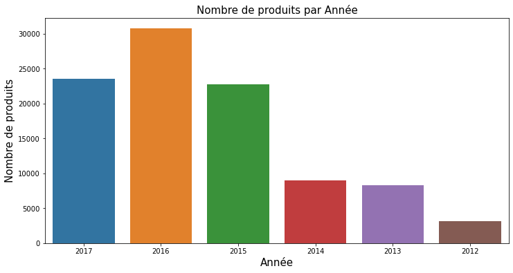

```python
fig = plt.figure(figsize=(12, 6))
sns.countplot(x=df["Year"].sort_values(ascending=False))
plt.xlabel('Année', fontsize=15)
plt.ylabel('Nombre de produits', fontsize=15)
plt.title('Nombre de produits par Année', fontsize=15)
plt.show()
```

Pour notre analyse, notre plus grand contributeur sera openfoodfacts

```python
df['creator'].value_counts()
```

```
openfoodfacts-contributors    28863
kiliweb                       13878
date-limite-app                7800
tacite                         7068
sebleouf                       5537
                              ...
gatto                             1
pilou                             1
anne-06                           1
laetimarie                        1
lann                              1
Name: creator, Length: 2583, dtype: int64
```

|  | Total | Percent |
| --- | --- | --- |
| fiber_100g | 52185 | 0.534973 |
| carbohydrates_100g | 50903 | 0.521831 |
| fat_100g | 50476 | 0.517453 |
| nutrition-score-fr_100g | 36648 | 0.375696 |
| nutrition_grade_fr | 36648 | 0.375696 |
| saturated-fat_100g | 35698 | 0.365957 |
| sugars_100g | 35562 | 0.364563 |
| salt_100g | 35499 | 0.363917 |
| proteins_100g | 33796 | 0.346459 |
| energy_100g | 33529 | 0.343721 |
| pnns_groups_1 | 33416 | 0.342563 |
| product_name | 7159 | 0.073390 |
| created_datetime | 0 | 0.000000 |
| countries | 0 | 0.000000 |
| creator | 0 | 0.000000 |
| Year | 0 | 0.000000 |

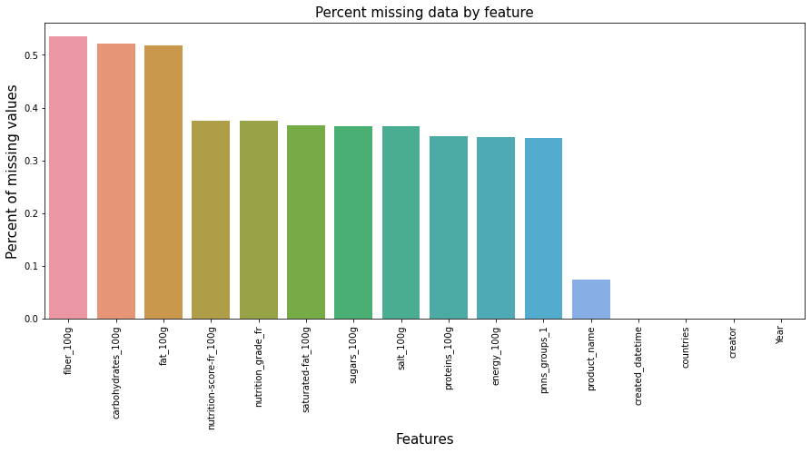

```python
total = df.isnull().sum().sort_values(ascending=False)
percent = (df.isnull().sum()/df.isnull().count()).sort_values(ascending=False)
missing_data = pd.concat([total, percent], axis=1, keys=['Total', 'Percent'])
f, ax = plt.subplots(figsize=(15, 6))
plt.xticks(rotation='90')
sns.barplot(x=missing_data.index, y=missing_data['Percent'])
plt.xlabel('Features', fontsize=15)
plt.ylabel('Percent of missing values', fontsize=15)
plt.title('Percent missing data by feature', fontsize=15)
missing_data
```

## Feature Pnns group1

```python
df['pnns_groups_1'].nunique()
```

```
13
```

```python
df['pnns_groups_1'].value_counts()
```

```
unknown                    12262
Sugary snacks               9259
Fish Meat Eggs              6752
Beverages                   6524
Milk and dairy products     6341
Composite foods             6033
Cereals and potatoes        6025
Fruits and vegetables       4044
Fat and sauces              3773
Salty snacks                2100
fruits-and-vegetables        546
sugary-snacks                470
cereals-and-potatoes           2
Name: pnns_groups_1, dtype: int64
```

```python
# supression de Unknown
df.drop(index=df[df['pnns_groups_1'] == 'unknown'].index, inplace=True)
```

```python
list(pd.unique(df.pnns_groups_1.values))
```

```
[nan,
 'Cereals and potatoes',
 'Sugary snacks',
 'Beverages',
 'Fish Meat Eggs',
 'Composite foods',
 'Fruits and vegetables',
 'Milk and dairy products',
 'Salty snacks',
 'Fat and sauces',
 'fruits-and-vegetables',
 'sugary-snacks',
 'cereals-and-potatoes']
```

```python
df = df.replace("sugary-snacks", "Sugary snacks")
df = df.replace("cereals-and-potatoes", "Cereals and potatoes")
df = df.replace("fruits-and-vegetables", "Fruits and vegetables")
```

```python
list(pd.unique(df.pnns_groups_1.values))
```

```
[nan,
 'Cereals and potatoes',
 'Sugary snacks',
 'Beverages',
 'Fish Meat Eggs',
 'Composite foods',
 'Fruits and vegetables',
 'Milk and dairy products',
 'Salty snacks',
 'Fat and sauces']
```

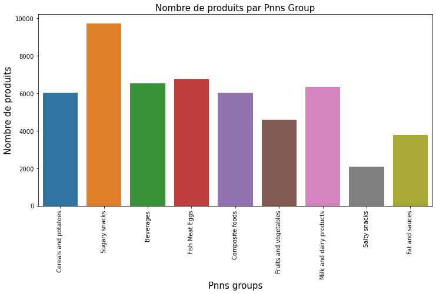

```python
fig = plt.figure(figsize=(12, 6))
sns.countplot(x=df["pnns_groups_1"])
plt.xlabel('Pnns groups', fontsize=15)
plt.ylabel('Nombre de produits', fontsize=15)
plt.title('Nombre de produits par Pnns Group', fontsize=15)
plt.xticks(rotation='90')
plt.show()
```

## Supression des features

Les features ayant servi au travail de filtrage précedement également seront supprimées pendant cette étape

```python
df.drop(['created_datetime',"creator",'countries','Year'], axis=1,inplace=True)
```

```python
df.shape
```

```
(85285, 12)
```

```python
df.info()
```

```
<class 'pandas.core.frame.DataFrame'>
Int64Index: 85285 entries, 0 to 320770
Data columns (total 12 columns):
 #   Column                   Non-Null Count  Dtype
---  ------                   --------------  -----
 0   product_name             79171 non-null  object
 1   fat_100g                 40341 non-null  float64
 2   sugars_100g              54594 non-null  float64
 3   energy_100g              56311 non-null  float64
 4   carbohydrates_100g       39937 non-null  float64
 5   saturated-fat_100g       54498 non-null  float64
 6   fiber_100g               40128 non-null  float64
 7   proteins_100g            56088 non-null  float64
 8   salt_100g                54643 non-null  float64
 9   nutrition-score-fr_100g  53791 non-null  float64
 10  pnns_groups_1            51869 non-null  object
 11  nutrition_grade_fr       53791 non-null  object
dtypes: float64(9), object(3)
memory usage: 10.5+ MB
```

## Duplicated Values

Nous nous interessons maintenant aux lignes dupliquées

```python
# combien de valeurs manquantes dans les duplicated
df[df.duplicated()].isna().sum()
```

```
product_name               5985
fat_100g                   8402
sugars_100g                8376
energy_100g                8363
carbohydrates_100g         8411
saturated-fat_100g         8376
fiber_100g                 8751
proteins_100g              8364
salt_100g                  8369
nutrition-score-fr_100g    8376
pnns_groups_1              7061
nutrition_grade_fr         8376
dtype: int64
```

```python
df_duplicated = df.drop_duplicates()

print(
    f"Il y a un total de {len(df) - len(df_duplicated)} lignes dupliquées.")
```

```
Il y a un total de 9180 lignes dupliquées.
```

```python
df = df_duplicated
```

# Traitement des données ( imputation, gestion des valeurs aberrantes / manquantes)

Traiter les données manquantes revient à “réparer” le jeu de données pour qu’il puisse être utilisable par les algorithmes de Machine Learning. La réparation d’un jeu de données peut prendre plusieurs formes : Comme supprimer les donner manquantes ou les remplacer les valeurs manquantes (on parle d’imputation).

## Product name

Nous devons vérifier les produits présents plusieurs fois dans notre dataset (*produits dupliqués*). IL s'agit de les quantifier et ensuite d'appliquer un group by avec une stratégie de regroupement par la mediane

```python
# produits dupliqués
df['product_name'].value_counts()
```

```
Mayonnaise                                                      40
Orange                                                          39
Huile d'olive vierge extra                                      38
Jus d'orange                                                    33
Moutarde de Dijon                                               33
                                                                ..
MACARONIS MAIS SARRASIN SANS GLUTEN                              1
Camembert 8 portions                                             1
Préparation Pour Crème Pâtissière Onctueuse Alsa, 3 Sachets,     1
Citrons Confits                                                  1
L'Emmental français (29 % MG)                                    1
Name: product_name, Length: 64989, dtype: int64
```

```python
len(df['product_name'].unique())
```

```
64990
```

Nous pouvons observer que nous avons 64990 produits uniques

```python
# group by et appliquer d'une stratégie regroupement mediane
df = df.groupby("product_name")[["fat_100g", "sugars_100g", "energy_100g", "carbohydrates_100g",
                                 "saturated-fat_100g", "fiber_100g", "proteins_100g",
                                 "salt_100g",'nutrition-score-fr_100g']].agg(lambda x: x.median())

df.reset_index(inplace=True)
```

```python
df.shape
```

```
(64989, 10)
```

Pour la feature product name, nous allons devoir gérer des valeurs manquantes. Il ne sera pas possible de conserver dans notre dataset des row ou la feature product name est manquante. Nous éliminerons les données na

```python
df_categorial_feature = df_duplicated[[
    'product_name', 'pnns_groups_1', 'nutrition_grade_fr']]
```

```python
df_categorial_feature.drop_duplicates(subset=['product_name'],inplace=True)
```

```python
df_categorial_feature.shape
```

```
(64990, 3)
```

```python
df_merge_product=pd.merge(df,df_categorial_feature, on='product_name')
```

```python
df_merge_product.shape
```

```
(64989, 12)
```

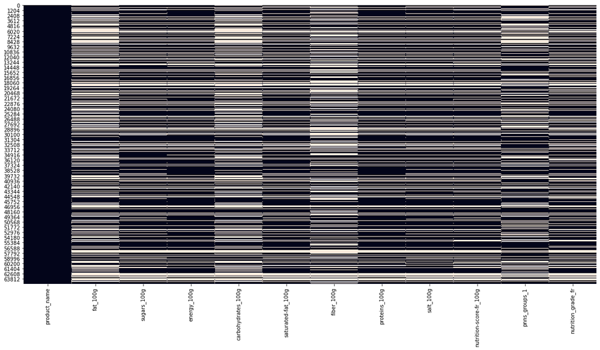

```python
plt.figure(figsize=(20,10))
sns.heatmap(df_merge_product.isna(), cbar=False)
```

## Nutritionnal values : Valeurs aberrantes

Comme vu précedemment, **Open Food Facts** est un projet collaboratif, chaque utilisateur peut librement renseigner les valeurs nutritionnelles en Gramme et de 0 à 100g pour chaque produit sauf pour le cas de l'énergie diffère. Vérifions Avant/ Après cette opération sur les valeurs nutritionnelles

```python
df_after = df_merge_product.copy()
```

```python
# définition du nutritional value 100g
nutritional_value_100g = ['fat_100g', 'sugars_100g',
                          'carbohydrates_100g', 'saturated-fat_100g', 'fiber_100g',
                          'proteins_100g', 'salt_100g']
```

```python
def range_0_100(df, cols):
    for col in cols:
        df.loc[df[col]>100,col] = np.nan
        df.loc[df[col]<0,col] = np.nan
```

```python
range_0_100(df_after, nutritional_value_100g)
```

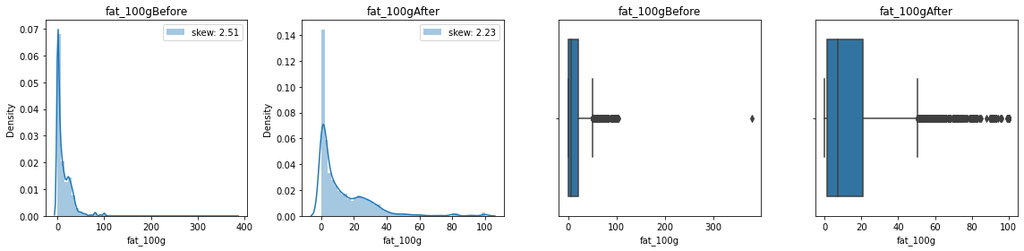

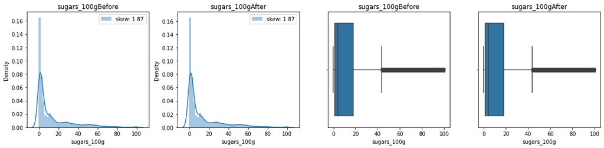

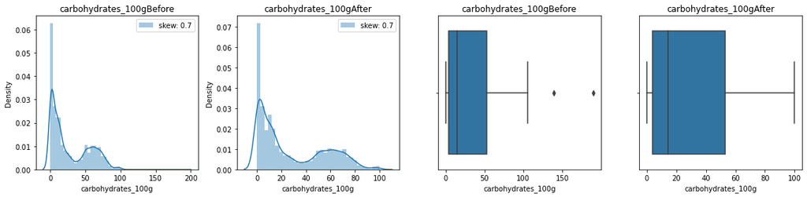

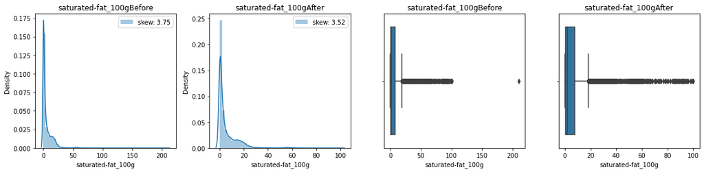

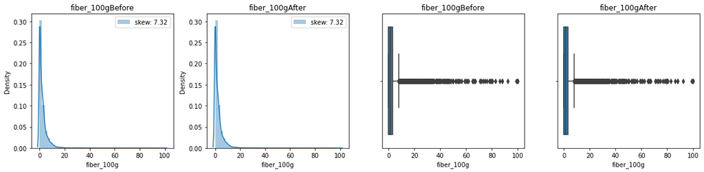

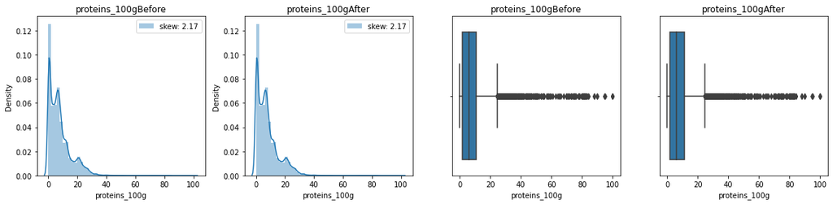

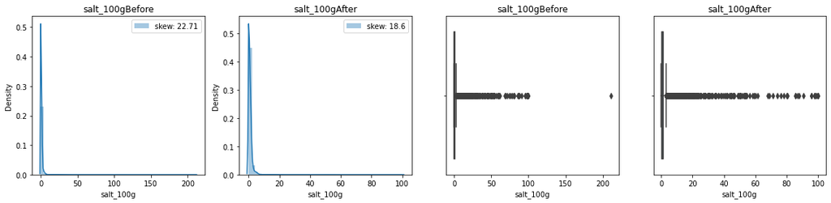

```python
# réprésentation avec un displot avant/après et un boxplot avant/après
for col in nutritional_value_100g:
    plt.figure(figsize=(16, 4))

    plt.subplot(141)
    sns.distplot(df_merge_product[col], label="skew: "+str(np.round(df_merge_product[col].skew(),2)))
    plt.title(col + "Before")
    plt.legend()

    plt.subplot(142)
    sns.distplot(df_after[col], label="skew: "+str(np.round(df_after[col].skew(),2)))
    plt.title(col + "After")
    plt.legend()

    plt.subplot(143)
    sns.boxplot(df_merge_product[col])
    plt.title(col + "Before")

    plt.subplot(144)
    sns.boxplot(df_after[col])
    plt.title(col + "After")
    plt.tight_layout()
    plt.show()
```

### Fat_100g

vérification des valeurs abérantes pour la feature fat_100g. Nous pouvons contacter que 2 produits sont avec des valeurs qui dépasse 100g

```python
#min()
df_merge_product['fat_100g'].min()
```

```
0.0
```

```python
#max()
df_merge_product['fat_100g'].max()
```

```
380.0
```

```python
# vérification des produits
df_merge_product[df_merge_product['fat_100g']>100]
```

|  | product_name | fat_100g | sugars_100g | energy_100g | carbohydrates_100g | saturated-fat_100g | fiber_100g | proteins_100g | salt_100g | nutrition-score-fr_100g | pnns_groups_1 | nutrition_grade_fr |
| --- | --- | --- | --- | --- | --- | --- | --- | --- | --- | --- | --- | --- |
| 25242 | Graine de couscous moyen | 105.0 | 2.5 | 1482.0 | 70.0 | 0.3 | NaN | 12.0 | 0.01 | -1.0 | Cereals and potatoes | a |
| 63760 | mini choux goût fromage de chèvre - poivre | 380.0 | 22.7 | 18700.0 | 190.0 | 210.0 | 0.0 | 0.0 | 9.33 | 35.0 | Salty snacks | e |

### saturated-fat_100g

vérification des valeurs abérantes pour la feature saturated-fat_100g. Nous pouvons constater qu'il y un seul produit au dessus des 100g

```python
#min()
df_merge_product['saturated-fat_100g'].min()
```

```
0.0
```

```python
#max()
df_merge_product['saturated-fat_100g'].max()
```

```
210.0
```

```python
df_merge_product[df_merge_product['saturated-fat_100g']>100]
```

|  | product_name | fat_100g | sugars_100g | energy_100g | carbohydrates_100g | saturated-fat_100g | fiber_100g | proteins_100g | salt_100g | nutrition-score-fr_100g | pnns_groups_1 | nutrition_grade_fr |
| --- | --- | --- | --- | --- | --- | --- | --- | --- | --- | --- | --- | --- |
| 63760 | mini choux goût fromage de chèvre - poivre | 380.0 | 22.7 | 18700.0 | 190.0 | 210.0 | 0.0 | 0.0 | 9.33 | 35.0 | Salty snacks | e |

### sugars_100g

```python
#min()
df_merge_product['sugars_100g'].min()
```

```
-0.1
```

```python
#max()
df_merge_product['sugars_100g'].max()
```

```
100.0
```

```python
df_merge_product[df_merge_product['sugars_100g']<0]
```

|  | product_name | fat_100g | sugars_100g | energy_100g | carbohydrates_100g | saturated-fat_100g | fiber_100g | proteins_100g | salt_100g | nutrition-score-fr_100g | pnns_groups_1 | nutrition_grade_fr |
| --- | --- | --- | --- | --- | --- | --- | --- | --- | --- | --- | --- | --- |
| 9737 | Caprice des dieux | 30.0 | -0.1 | 1379.0 | 0.8 | 21.0 | NaN | 15.3 | 1.4 | 15.0 | Milk and dairy products | d |

### carbohydrates_100g

```python
#min()
df_merge_product['carbohydrates_100g'].min()
```

```
0.0
```

```python
#max()
df_merge_product['carbohydrates_100g'].max()
```

```
190.0
```

```python
df_merge_product[df_merge_product['carbohydrates_100g']>100]
```

|  | product_name | fat_100g | sugars_100g | energy_100g | carbohydrates_100g | saturated-fat_100g | fiber_100g | proteins_100g | salt_100g | nutrition-score-fr_100g | pnns_groups_1 | nutrition_grade_fr |
| --- | --- | --- | --- | --- | --- | --- | --- | --- | --- | --- | --- | --- |
| 4453 | Banane sèche | 0.0 | 41.5 | 1259.0 | 139.0 | 0.0 | 0.0 | 5.0 | 0.00000 | 4.0 | Fruits and vegetables | c |
| 41989 | Palets pur beurre | 52.0 | 52.0 | 3925.0 | 106.0 | 35.5 | 3.0 | 10.0 | 1.30048 | 31.0 | NaN | NaN |
| 63760 | mini choux goût fromage de chèvre - poivre | 380.0 | 22.7 | 18700.0 | 190.0 | 210.0 | 0.0 | 0.0 | 9.33000 | 35.0 | Salty snacks | e |

### fiber_100g

Vérification des valeurs abérantes pour la feature fiber_100g. Nous pouvons observer aucune donnée abérantes sur cette feature

```python
#min()
df_merge_product['fiber_100g'].min()
```

```
0.0
```

```python
#max()
df_merge_product['fiber_100g'].max()
```

```
100.0
```

### proteins_100g

Vérification des valeurs abérantes pour la feature proteins_100g. Nous pouvons observer aucune donnée abérantes sur cette feature

```python
#min()
df_merge_product['proteins_100g'].min()
```

```
0.0
```

```python
#max()
df_merge_product['proteins_100g'].max()
```

```
100.0
```

### salt_100g

```python
#min()
df_merge_product['salt_100g'].min()
```

```
0.0
```

```python
#max()
df_merge_product['salt_100g'].max()
```

```
211.0
```

```python
df_merge_product[df_merge_product['salt_100g']>100]
```

|  | product_name | fat_100g | sugars_100g | energy_100g | carbohydrates_100g | saturated-fat_100g | fiber_100g | proteins_100g | salt_100g | nutrition-score-fr_100g | pnns_groups_1 | nutrition_grade_fr |
| --- | --- | --- | --- | --- | --- | --- | --- | --- | --- | --- | --- | --- |
| 29159 | Keeny Bio | 23.0 | 26.7 | 1720.0 | 47.8 | 3.33 | 0.741 | 6.3 | 211.0 | 22.0 | Sugary snacks | e |

## Energy_100g

Quelle unité de mesure Cal ou Joules? Vérifions

```python
df_merge_product['energy_100g'].describe()
```

```
count    47048.00000
mean      1114.19673
std        789.42070
min          0.00000
25%        430.87500
50%       1029.00000
75%       1653.00000
max      18700.00000
Name: energy_100g, dtype: float64
```

```python
df_merge_product[df_merge_product['product_name']=='Cookies']
```

|  | product_name | fat_100g | sugars_100g | energy_100g | carbohydrates_100g | saturated-fat_100g | fiber_100g | proteins_100g | salt_100g | nutrition-score-fr_100g | pnns_groups_1 | nutrition_grade_fr |
| --- | --- | --- | --- | --- | --- | --- | --- | --- | --- | --- | --- | --- |
| 14561 | Cookies | 24.05 | 33.0 | 2061.0 | 62.15 | 12.0 | 3.4 | 5.9 | 0.73 | 23.0 | Sugary snacks | e |

Selon USDA, Le cookie correspond à environ 502 calories soit environ 2100 Joules; Nous pouvons admettre qu'il semble que nos données soient en Joules

Parmi les aliments les plus caloriques, on retrouve les graisses d’origine animale Ce type de graisse se caractérise par une forte teneur en gras saturé, source de cholestérol, tout en étant dépourvu de nutriments intéressants. L’huile de poisson et le lard par exemple apportent près de 900 calories par 100 grammes soit 3800 J pour 100g

```python
#min()
df_merge_product['energy_100g'].min()
```

```
0.0
```

```python
#max()
df_merge_product['energy_100g'].max()
```

```
18700.0
```

```python
print(
    f"Il y a un total de {len(df_merge_product[df_merge_product['energy_100g']>3800])} produits ou l'énergie est supérieure à 3800Joules. Donc autant de produits avec des valeurs abérantes")
```

```
Il y a un total de 70 produits ou l'énergie est supérieure à 3800Joules. Donc autant de produits avec des valeurs abérantes
```

```python
df_merge_product[df_merge_product['energy_100g']>3800]
```

|  | product_name | fat_100g | sugars_100g | energy_100g | carbohydrates_100g | saturated-fat_100g | fiber_100g | proteins_100g | salt_100g | nutrition-score-fr_100g | pnns_groups_1 | nutrition_grade_fr |
| --- | --- | --- | --- | --- | --- | --- | --- | --- | --- | --- | --- | --- |
| 834 | 1KG Nuggets Poulet Maitre Coq | NaN | 1.30 | 4289.0 | NaN | 2.40 | 0.0 | 12.00 | 1.40000 | 18.0 | NaN | d |
| 893 | 2 Eclairs gourmands citron meringué | NaN | 35.80 | 5272.0 | NaN | 7.20 | 1.0 | 5.00 | 0.39000 | 24.0 | NaN | e |
| 3860 | Assortiment de roulades | NaN | 0.90 | 4071.0 | NaN | 6.70 | 0.0 | 13.50 | 2.50000 | 26.0 | NaN | e |
| 4344 | Baguettines viennoises briochées | NaN | 1.00 | 5347.0 | NaN | 1.70 | 2.5 | 8.70 | 1.00000 | 12.0 | NaN | d |
| 4672 | Barres de son d'avoine | NaN | 3.00 | 5749.0 | NaN | 1.00 | 8.0 | 19.50 | 0.36000 | 6.0 | NaN | c |
| 5959 | Biscuits Son D'avoine Nappés Chocolat 12 Biscuits | NaN | 0.60 | 6063.0 | NaN | 3.60 | 10.1 | 13.80 | 0.19000 | 8.0 | NaN | c |
| 7639 | Boulgour Bio Traditionnel | NaN | 1.90 | 6134.0 | NaN | 0.30 | 7.3 | 11.50 | 0.02000 | 0.0 | NaN | b |
| 10865 | Chevre Pane | NaN | 2.00 | 5205.0 | NaN | 12.00 | 0.0 | 14.00 | 1.30000 | 25.0 | NaN | e |
| 10943 | Chicken Cup Of Noodles | NaN | 4.00 | 4602.0 | NaN | 4.70 | 0.0 | 9.70 | 0.00000 | 14.0 | NaN | d |
| 11658 | Chocolat Liquide | NaN | 46.40 | 4786.0 | NaN | 0.50 | 0.0 | 1.60 | 0.29000 | 21.0 | NaN | e |
| 13927 | Confiserie Firenze Apfel Streuselkuchen Tiefge... | NaN | 18.50 | 4197.0 | NaN | 3.90 | 0.0 | 2.90 | 0.11000 | 17.0 | NaN | d |
| 14048 | Confiture Bonne Maman 370g | NaN | 59.00 | 4284.0 | NaN | 0.15 | 1.5 | 0.30 | 0.00000 | 18.0 | NaN | d |
| 14125 | Confiture Extra, 4 Fruits Rouges, 370 Grammes,... | NaN | 60.00 | 4305.0 | NaN | 0.00 | 0.0 | 0.50 | 0.00000 | 20.0 | NaN | e |
| 14264 | Confiture de Châtaignes d'Ardèche | NaN | 41.00 | 4159.0 | NaN | 0.20 | 2.3 | 0.46 | 0.01000 | 15.0 | Sugary snacks | d |
| 14479 | Confiture pastèque citron | 0.2 | 60.00 | 4410.0 | 61.0 | 0.20 | 0.5 | 0.30 | 0.05000 | 19.0 | Sugary snacks | e |
| 14976 | Cornetto Mini X8 Fruit | NaN | 24.00 | 5644.0 | NaN | 13.00 | 0.0 | 3.70 | 0.12000 | 25.0 | NaN | e |
| 15691 | Creme Fouettee | NaN | 12.00 | 5247.0 | NaN | 19.00 | 0.0 | 2.20 | 0.18700 | 22.0 | NaN | e |
| 16152 | Crousti tenders | NaN | 0.80 | 3883.0 | NaN | 1.20 | 0.0 | 17.00 | 1.80000 | 18.0 | NaN | d |
| 16587 | Crème Glacée Vanille, Coulis Caramel, Bac De 9... | NaN | 26.70 | 4209.0 | NaN | 5.60 | 0.2 | 2.30 | 0.13000 | 20.0 | NaN | e |
| 17176 | Cubes Moelleux De Noix De Coco Deshydratee | NaN | 40.00 | 5611.0 | NaN | 19.00 | 6.7 | 3.30 | 0.10000 | 23.0 | NaN | e |
| 18006 | Dejeunettes | NaN | 1.40 | 5774.0 | NaN | 0.70 | 0.0 | 10.00 | 1.60000 | 16.0 | NaN | d |
| 18430 | Diot de Savoie | NaN | 0.00 | 5050.0 | NaN | 9.70 | 0.0 | 18.00 | 22.00000 | 29.0 | NaN | e |
| 19470 | Eclats De Pois Chiches Bio ? 500G ? Priméal | NaN | 1.70 | 6117.0 | NaN | 0.60 | 12.6 | 23.90 | 0.01000 | 0.0 | NaN | b |
| 19480 | Ecoidees Sirop De Fleur De Coco Bio - Flacon | NaN | 28.00 | 5356.0 | NaN | 0.43 | 0.0 | 2.00 | 3.50000 | 26.0 | NaN | e |
| 19801 | Emmental français râpé au lait cru | 30.0 | 0.00 | 6803.0 | 0.8 | 19.00 | 1.1 | 29.00 | 0.50000 | 16.0 | Milk and dairy products | d |
| 21916 | Fit Chocolate | NaN | 3.03 | 6067.0 | NaN | 3.41 | 13.5 | 50.60 | 1.43000 | 14.0 | NaN | d |
| 22018 | Flammekueche Recette Alsacienne U Les Saveurs,... | NaN | 3.40 | 4125.0 | NaN | 4.80 | 2.2 | 8.10 | 1.80000 | 18.0 | NaN | d |
| 23339 | Fromage à Tartiner Au Poivre | NaN | 3.00 | 4356.0 | NaN | 24.00 | 0.0 | 6.00 | 1.30000 | 25.0 | NaN | e |
| 24303 | Gateau Amandes Et Chocolat | NaN | 44.00 | 3849.0 | NaN | 16.50 | 14.5 | 25.00 | 0.25000 | 25.0 | NaN | e |
| 24832 | Gnocchi E Pasta Fresca | NaN | 1.90 | 4828.0 | NaN | 3.52 | 2.3 | 9.80 | 1.12000 | 14.0 | NaN | d |
| 25895 | Gruyère France au lait cru (33% MG) | 33.0 | 0.50 | 7029.0 | 0.5 | 21.00 | NaN | 27.00 | 0.90000 | 18.0 | Milk and dairy products | d |
| 26339 | Halva with Almonds | 36.8 | 32.00 | 9983.0 | 44.2 | 7.80 | NaN | 12.90 | 0.00000 | 24.0 | Sugary snacks | e |
| 26417 | Haribo Goldbären Dose 450G | NaN | 35.00 | 4648.0 | NaN | 84.00 | 88.0 | 8.00 | 14.00000 | 32.0 | NaN | e |
| 27306 | Huiles vierge biologique de Colza - première p... | 100.0 | 0.00 | 15481.0 | 0.0 | 8.00 | 0.0 | 0.00 | 0.00000 | 10.0 | Fat and sauces | c |
| 28394 | Jamón de Cebo Iberico | NaN | 0.50 | 5611.0 | NaN | 22.00 | 0.7 | 29.00 | 4.20000 | 30.0 | NaN | e |
| 30586 | La saucisse bien élevée Saucisses avec des mor... | NaN | 0.50 | 3979.0 | NaN | 6.50 | 0.0 | 17.00 | 1.60000 | 22.0 | NaN | e |
| 31215 | Lardons Fumés Sans Couenne | NaN | 2.00 | 4941.0 | NaN | 8.70 | 0.0 | 16.40 | 2.50000 | 28.0 | NaN | e |
| 32782 | Lentilles vertes précuites 10min LE BON SEMEUR | NaN | 0.70 | 4987.0 | NaN | 0.20 | 27.0 | 24.00 | 0.04000 | 0.0 | NaN | b |
| 33900 | Lot De 4 Baguettes | NaN | 0.00 | 4184.0 | NaN | 0.00 | 0.0 | 0.00 | 0.00000 | 10.0 | NaN | c |
| 34478 | Madeleines Au Miel (14% De Miel) | NaN | 36.00 | 5104.0 | NaN | 16.00 | 0.0 | 5.00 | 0.70000 | 30.0 | NaN | e |
| 34733 | Maitre Prunille pruneaux d'agen 25/30 | NaN | 37.00 | 4431.0 | NaN | 0.20 | 6.6 | 1.40 | 0.00000 | 13.0 | NaN | d |
| 35896 | Miel D'eucalyptus | NaN | 80.00 | 5749.0 | NaN | 0.00 | 0.0 | 0.40 | 0.01000 | 20.0 | NaN | e |
| 36849 | Mini pizza chevre lardon | NaN | 4.30 | 4092.0 | NaN | 4.20 | 0.0 | 9.10 | 1.08000 | 18.0 | NaN | d |
| 36938 | Mini-bonbons Sans Sucres, Menthe | NaN | 0.50 | 4058.0 | NaN | 0.00 | 0.0 | 0.00 | 0.02000 | 10.0 | Sugary snacks | c |
| 38595 | Multigrain knacke | NaN | 62.50 | 5653.0 | NaN | 0.60 | 16.0 | 9.10 | 1.80000 | 22.0 | NaN | e |
| 39037 | Nakd Strawberry Crunch | NaN | 44.80 | 6268.0 | NaN | 9.10 | 4.5 | 18.40 | 0.60000 | 25.0 | NaN | e |
| 40579 | Olives Cocktail Pimentées, Le Sachet De | NaN | 0.00 | 3908.0 | NaN | 3.26 | 6.7 | 1.20 | 2.50000 | 18.0 | NaN | d |
| 41389 | Pain &quot;Mini-boules Rustique&quot; | NaN | 1.60 | 4699.0 | NaN | 0.30 | 4.4 | 8.60 | 1.30000 | 10.0 | NaN | c |
| 41461 | Pain De Table | NaN | 7.50 | 4883.0 | NaN | 1.00 | 3.0 | 8.50 | 1.25000 | 12.0 | NaN | d |
| 41845 | Pains Au Chocolat | NaN | 13.40 | 6109.0 | NaN | 19.00 | 0.0 | 7.30 | 0.90000 | 25.0 | Sugary snacks | e |
| 41989 | Palets pur beurre | 52.0 | 52.00 | 3925.0 | 106.0 | 35.50 | 3.0 | 10.00 | 1.30048 | 31.0 | NaN | NaN |
| 42134 | Panes Façon Cordon Bleu Vegetarien | NaN | 0.40 | 4217.0 | NaN | 2.90 | 5.2 | 13.90 | 1.60000 | 13.0 | NaN | d |
| 47287 | Purée Nature | 1.2 | 2.70 | 6138.0 | 28.9 | 0.80 | 9.7 | 5.20 | 0.10000 | NaN | Cereals and potatoes | NaN |
| 49346 | Rillettes De Poulet Roti | NaN | 0.10 | 5720.0 | NaN | 9.20 | 0.0 | 16.80 | 1.00000 | 23.0 | NaN | e |
| 49467 | Rillettes de sardine de Bretagne | NaN | 0.10 | 4000.0 | NaN | 4.60 | 0.0 | 14.00 | 1.10000 | 18.0 | Fish Meat Eggs | d |
| 50514 | Ryvita Crispbread Pumpkin & Oat | NaN | 4.90 | 5732.0 | NaN | 1.30 | 18.3 | 11.20 | 0.61000 | 9.0 | NaN | c |
| 51726 | Sardines A L'huile De Tournesol | NaN | 0.00 | 4485.0 | NaN | 3.50 | 0.0 | 24.30 | 1.00000 | 17.0 | Fish Meat Eggs | d |
| 52389 | Sauce beurre blanc et citron confit | NaN | 2.90 | 4607.0 | NaN | 17.00 | 2.0 | 0.50 | 1.20000 | 23.0 | NaN | e |
| 54115 | Sirop Citron Bio au pur sucre de canne | NaN | 69.30 | 4929.0 | NaN | 0.10 | 0.0 | 0.10 | 0.10000 | 20.0 | NaN | e |
| 54149 | Sirop Frucci, Thé Pêche | NaN | 71.70 | 5100.0 | NaN | 0.00 | 0.0 | 0.00 | 0.10500 | 20.0 | NaN | e |
| 54152 | Sirop Grenadine - Recette William | NaN | 73.50 | 5268.0 | NaN | 0.10 | 0.0 | 0.50 | 0.01000 | 20.0 | Beverages | e |
| 54172 | Sirop Saveur pina Colada | NaN | 79.00 | 5619.0 | NaN | 0.50 | 0.0 | 0.50 | 0.02000 | 20.0 | NaN | e |
| 54252 | Sirop de cerise | NaN | 83.00 | 5904.0 | NaN | 0.00 | 0.0 | 0.00 | 0.00000 | 20.0 | Beverages | e |
| 54259 | Sirop de citron pressor | NaN | 62.10 | 4418.0 | NaN | 0.00 | 0.0 | 0.00 | 0.00000 | 20.0 | NaN | e |
| 54613 | Sodastream - Concentré Cola + 50% Gratuit (300... | NaN | 85.00 | 6046.0 | NaN | 0.00 | 0.0 | 0.00 | 0.20000 | 20.0 | NaN | e |
| 57271 | Tartelettes aux framboises sur crème pâtissièr... | NaN | 15.00 | 3904.0 | NaN | 5.90 | 0.0 | 2.70 | 0.10000 | 18.0 | NaN | d |
| 57477 | Tawny' Orange | NaN | 65.00 | 5054.0 | NaN | 0.00 | 0.0 | 0.00 | 0.00000 | 20.0 | NaN | e |
| 58708 | Tomatentapenade Bakje 150 Gram (baresa) Koeling | NaN | 13.00 | 4841.0 | NaN | 2.90 | 0.0 | 3.00 | 2.90000 | 24.0 | NaN | e |
| 60918 | Vinaigrette miel moutarde | NaN | 9.30 | 6017.0 | NaN | 2.80 | 0.4 | 1.50 | 2.30000 | 24.0 | NaN | e |
| 63760 | mini choux goût fromage de chèvre - poivre | 380.0 | 22.70 | 18700.0 | 190.0 | 210.00 | 0.0 | 0.00 | 9.33000 | 35.0 | Salty snacks | e |

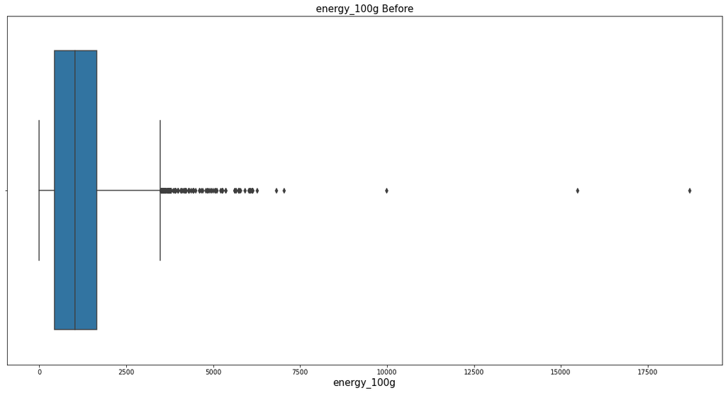

```python
plt.figure(figsize=(20,10))
sns.boxplot(df_merge_product['energy_100g'])
plt.title("energy_100g Before", fontsize=15)
plt.xlabel('energy_100g', fontsize=15)
```

```python
df_after.loc[df_after['energy_100g']>3800,'energy_100g'] = np.nan
```

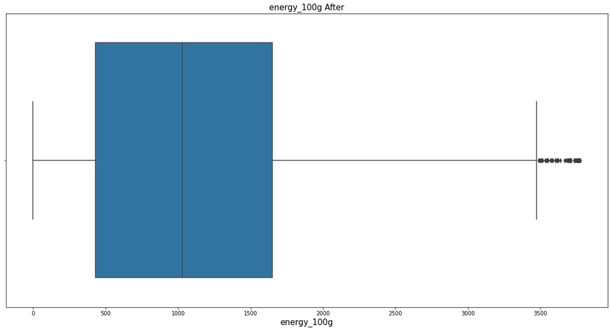

```python
plt.figure(figsize=(20,10))
sns.boxplot(df_after['energy_100g'])
plt.title("energy_100g After", fontsize=15)
plt.xlabel('energy_100g', fontsize=15)
```

Nous venons de terminer cette étape de nettoyage en éliminant les valeurs abérréantes, celles hors du cadre de l'unité des différentes features nutritionnelle.

```python
df_nutriscore = df_after.copy()
```

## Nutrition-score-fr_100g

- Nutri-Score A : -15 à -1
- Nutri-Score B : 0 à 2
- Nutri-Score C : 3 à 10
- Nutri-Score D : 11 à 18
- Nutri-Score E : 19 à 40

Le nutrition-score-fr_100g doit etre compris entre l'invervalle -15 et 40, les valeurs au delà sont considérées comme abérantes et necessiteront d'etre retirées de notre dataset

```python
df_nutriscore['nutrition-score-fr_100g'] = df_nutriscore['nutrition-score-fr_100g'].round(
    0)
```

```python
# vérification des produits ou le nutrition score >40
df_nutriscore[df_nutriscore['nutrition-score-fr_100g'] > 40]
```

|  | product_name | fat_100g | sugars_100g | energy_100g | carbohydrates_100g | saturated-fat_100g | fiber_100g | proteins_100g | salt_100g | nutrition-score-fr_100g | pnns_groups_1 | nutrition_grade_fr |
| --- | --- | --- | --- | --- | --- | --- | --- | --- | --- | --- | --- | --- |

```python
# vérification des produits ou le nutrition score <-15
df_nutriscore[df_nutriscore['nutrition-score-fr_100g'] < -15]
```

|  | product_name | fat_100g | sugars_100g | energy_100g | carbohydrates_100g | saturated-fat_100g | fiber_100g | proteins_100g | salt_100g | nutrition-score-fr_100g | pnns_groups_1 | nutrition_grade_fr |
| --- | --- | --- | --- | --- | --- | --- | --- | --- | --- | --- | --- | --- |

Aucune abbération pour cette feature, Dans notre dataset nous disposons de la feature **nutrition grade**, interesssons nous à cette feature et faisons un parallèle avec la feature nutrition score. Les deux étant liées et voyons la cohérence entre elles

## Nutrition_grade_fr

Vérification que nos données sur cette feature **nutrition grade** vont de la lettre A à la lettre E

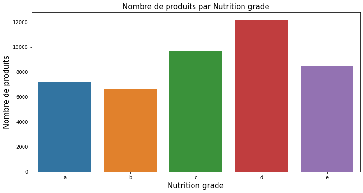

```python
fig = plt.figure(figsize=(12, 6))
sns.countplot(x=df_nutriscore["nutrition_grade_fr"].sort_values(ascending=True))
plt.xlabel('Nutrition grade', fontsize=15)
plt.ylabel('Nombre de produits', fontsize=15)
plt.title('Nombre de produits par Nutrition grade', fontsize=15)
plt.show()
```

Vérifions que les **nutrition-score-fr_100g** et les **nutrition_grade_fr** sont correctement associés. Pour cela, nous croisons les variables dans un même tableau.

- Nutri-Score A : -15 à -1
- Nutri-Score B : 0 à 2
- Nutri-Score C : 3 à 10
- Nutri-Score D : 11 à 18
- Nutri-Score E : 19 à 40

```python
#pd.cross tab
pd.crosstab(
    df_nutriscore['nutrition-score-fr_100g'], df_nutriscore['nutrition_grade_fr'])
```

| nutrition_grade_fr nutrition-score-fr_100g | a | b | c | d | e |
| --- | --- | --- | --- | --- | --- |
| -14.0 | 3 | 0 | 0 | 0 | 0 |
| -13.0 | 9 | 0 | 0 | 0 | 0 |
| -12.0 | 15 | 0 | 0 | 0 | 0 |
| -11.0 | 41 | 0 | 0 | 0 | 0 |
| -10.0 | 60 | 0 | 0 | 0 | 0 |
| -9.0 | 84 | 0 | 1 | 0 | 0 |
| -8.0 | 144 | 1 | 0 | 0 | 0 |
| -7.0 | 210 | 2 | 0 | 0 | 0 |
| -6.0 | 900 | 4 | 0 | 0 | 0 |
| -5.0 | 979 | 12 | 0 | 0 | 0 |
| -4.0 | 1009 | 27 | 0 | 1 | 0 |
| -3.0 | 878 | 14 | 2 | 0 | 0 |
| -2.0 | 1196 | 42 | 2 | 3 | 0 |
| -1.0 | 1525 | 18 | 5 | 1 | 0 |
| 0.0 | 66 | 2303 | 4 | 0 | 0 |
| 1.0 | 16 | 2132 | 14 | 0 | 1 |
| 2.0 | 10 | 2050 | 357 | 5 | 2 |
| 3.0 | 2 | 10 | 2046 | 1 | 0 |
| 4.0 | 4 | 11 | 1857 | 6 | 0 |
| 5.0 | 1 | 4 | 1322 | 11 | 0 |
| 6.0 | 4 | 7 | 716 | 205 | 0 |
| 7.0 | 0 | 4 | 648 | 105 | 0 |
| 8.0 | 0 | 4 | 832 | 130 | 1 |
| 9.0 | 1 | 0 | 806 | 137 | 3 |
| 10.0 | 0 | 3 | 971 | 32 | 148 |
| 11.0 | 0 | 1 | 17 | 1755 | 92 |
| 12.0 | 1 | 1 | 12 | 1542 | 120 |
| 13.0 | 0 | 0 | 3 | 1529 | 174 |
| 14.0 | 0 | 1 | 9 | 2020 | 116 |
| 15.0 | 0 | 0 | 2 | 1411 | 171 |
| 16.0 | 1 | 0 | 5 | 1169 | 105 |
| 17.0 | 0 | 1 | 2 | 1037 | 84 |
| 18.0 | 0 | 0 | 2 | 1030 | 67 |
| 19.0 | 1 | 3 | 0 | 14 | 1243 |
| 20.0 | 0 | 0 | 0 | 13 | 1195 |
| 21.0 | 0 | 0 | 0 | 5 | 882 |
| 22.0 | 0 | 0 | 0 | 5 | 722 |
| 23.0 | 0 | 0 | 0 | 0 | 650 |
| 24.0 | 0 | 0 | 0 | 0 | 627 |
| 25.0 | 0 | 0 | 0 | 1 | 721 |
| 26.0 | 0 | 0 | 0 | 0 | 673 |
| 27.0 | 0 | 0 | 0 | 0 | 348 |
| 28.0 | 0 | 0 | 0 | 0 | 171 |
| 29.0 | 0 | 0 | 0 | 0 | 46 |
| 30.0 | 0 | 0 | 0 | 0 | 27 |
| 31.0 | 0 | 0 | 0 | 0 | 13 |
| 32.0 | 0 | 0 | 0 | 0 | 21 |
| 33.0 | 0 | 0 | 0 | 0 | 7 |
| 34.0 | 0 | 0 | 0 | 0 | 2 |
| 35.0 | 0 | 0 | 0 | 0 | 7 |
| 36.0 | 0 | 0 | 0 | 0 | 7 |
| 40.0 | 0 | 0 | 0 | 0 | 1 |

On peut observer des erreurs pour certain produit, nous allons nous appuyer sur les valeurs du **nutrition-score-fr_100g** pour chaque produit et ainsi à l'aide d'une fonction nous pourrons implementer les valeurs corrects du nutrition grade

### Modification "nutrition_grade_fr"

Définition de la fonction qui retourne le bon nutrition grade en fonction de l'indice du nutrition score

```python
def nutrition_grade(x):
    if x >=-15 and x <=-1 :
        return 'A'
    elif x >=-0 and x <=2 :
        return 'B'
    elif x >=3 and x <=10:
        return 'C'
    elif x >=11 and x <=18 :
        return 'D'
    elif x >=19 and x <=40 :
        return 'E'
    else:
         return np.nan
```

```python
# apply
df_nutriscore["nutrition_grade_fr"] = df_nutriscore['nutrition-score-fr_100g'].apply(nutrition_grade)
```

```python
# pd.crosstab
pd.crosstab(df_nutriscore['nutrition-score-fr_100g'], df_nutriscore['nutrition_grade_fr'])
```

| nutrition_grade_fr nutrition-score-fr_100g | A | B | C | D | E |
| --- | --- | --- | --- | --- | --- |
| -14.0 | 3 | 0 | 0 | 0 | 0 |
| -13.0 | 9 | 0 | 0 | 0 | 0 |
| -12.0 | 16 | 0 | 0 | 0 | 0 |
| -11.0 | 43 | 0 | 0 | 0 | 0 |
| -10.0 | 64 | 0 | 0 | 0 | 0 |
| -9.0 | 86 | 0 | 0 | 0 | 0 |
| -8.0 | 149 | 0 | 0 | 0 | 0 |
| -7.0 | 217 | 0 | 0 | 0 | 0 |
| -6.0 | 929 | 0 | 0 | 0 | 0 |
| -5.0 | 1024 | 0 | 0 | 0 | 0 |
| -4.0 | 1068 | 0 | 0 | 0 | 0 |
| -3.0 | 911 | 0 | 0 | 0 | 0 |
| -2.0 | 1280 | 0 | 0 | 0 | 0 |
| -1.0 | 1577 | 0 | 0 | 0 | 0 |
| 0.0 | 0 | 2450 | 0 | 0 | 0 |
| 1.0 | 0 | 2203 | 0 | 0 | 0 |
| 2.0 | 0 | 2482 | 0 | 0 | 0 |
| 3.0 | 0 | 0 | 2098 | 0 | 0 |
| 4.0 | 0 | 0 | 1919 | 0 | 0 |
| 5.0 | 0 | 0 | 1353 | 0 | 0 |
| 6.0 | 0 | 0 | 960 | 0 | 0 |
| 7.0 | 0 | 0 | 769 | 0 | 0 |
| 8.0 | 0 | 0 | 993 | 0 | 0 |
| 9.0 | 0 | 0 | 966 | 0 | 0 |
| 10.0 | 0 | 0 | 1180 | 0 | 0 |
| 11.0 | 0 | 0 | 0 | 1911 | 0 |
| 12.0 | 0 | 0 | 0 | 1715 | 0 |
| 13.0 | 0 | 0 | 0 | 1751 | 0 |
| 14.0 | 0 | 0 | 0 | 2227 | 0 |
| 15.0 | 0 | 0 | 0 | 1626 | 0 |
| 16.0 | 0 | 0 | 0 | 1312 | 0 |
| 17.0 | 0 | 0 | 0 | 1145 | 0 |
| 18.0 | 0 | 0 | 0 | 1126 | 0 |
| 19.0 | 0 | 0 | 0 | 0 | 1291 |
| 20.0 | 0 | 0 | 0 | 0 | 1228 |
| 21.0 | 0 | 0 | 0 | 0 | 902 |
| 22.0 | 0 | 0 | 0 | 0 | 736 |
| 23.0 | 0 | 0 | 0 | 0 | 661 |
| 24.0 | 0 | 0 | 0 | 0 | 636 |
| 25.0 | 0 | 0 | 0 | 0 | 738 |
| 26.0 | 0 | 0 | 0 | 0 | 687 |
| 27.0 | 0 | 0 | 0 | 0 | 356 |
| 28.0 | 0 | 0 | 0 | 0 | 174 |
| 29.0 | 0 | 0 | 0 | 0 | 46 |
| 30.0 | 0 | 0 | 0 | 0 | 27 |
| 31.0 | 0 | 0 | 0 | 0 | 14 |
| 32.0 | 0 | 0 | 0 | 0 | 21 |
| 33.0 | 0 | 0 | 0 | 0 | 7 |
| 34.0 | 0 | 0 | 0 | 0 | 2 |
| 35.0 | 0 | 0 | 0 | 0 | 7 |
| 36.0 | 0 | 0 | 0 | 0 | 7 |
| 40.0 | 0 | 0 | 0 | 0 | 1 |

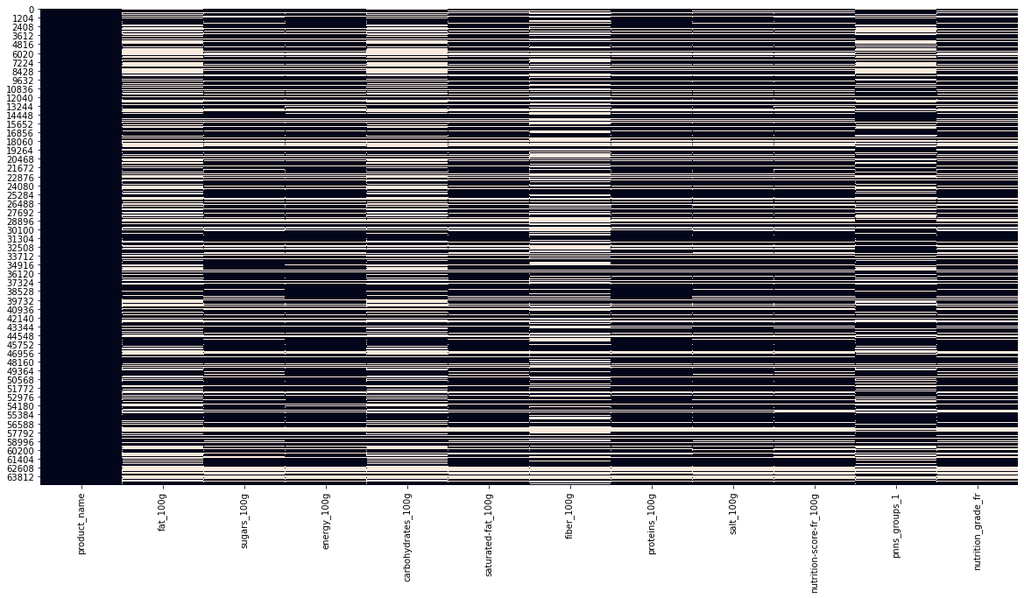

```python
plt.figure(figsize=(20,10))
sns.heatmap(df_nutriscore.isna(), cbar=False)
```

# Valeurs atypiques :

Vérification de la présence de valeurs atypiques de part et d'autre, catégorisées comme des valeurs "extérieures" ou "éloignées" (*Tukey, 1977*).

- Une valeur extérieure est définie comme une valeur inférieure au quartile inférieur moins 1,5 fois l'écart interquartile, ou supérieure au quartile supérieur plus 1,5 fois l'écart interquartile (les "limites intérieures").
- Une valeur très éloignée est définie comme une valeur inférieure au quartile inférieur moins 3 fois l'écart interquartile, ou supérieure au quartile supérieur plus 3 fois l'écart interquartile (les "limites extérieures").  
  Appliquons la méthode interquartile (Tukey) sur nos données nutritionnelle en fonction du Pnns groupe. Avant nous devions passer par une étape de Normalisation de nos données numériques sur l'ensemble des 64989 rows

## Normalisation

[figure not shown]

```python
import scipy.stats as stats
from sklearn.preprocessing import StandardScaler
```

```python
#df copy()
df_test_tukey = df_nutriscore.copy()
```

```python
numerical_value_100g = ['fat_100g', 'sugars_100g','energy_100g',
                        'carbohydrates_100g', 'saturated-fat_100g', 'fiber_100g',
                        'proteins_100g', 'salt_100g']
```

```python
X = df_test_tukey.select_dtypes(include=np.number)
```

```python
scaler = StandardScaler()
scaler.fit(X)
X_scaled = scaler.transform(X)
```

```python
df_scaled = pd.DataFrame(X_scaled, columns=X.columns)
```

```python
df_pnns = df_test_tukey['pnns_groups_1']
```

```python
df_scaled = pd.concat([df_pnns, df_scaled], axis=1)
```

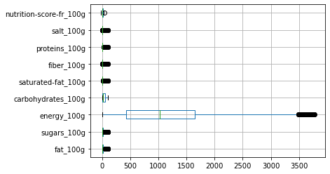

```python
# avant normalisation
df_nutriscore.boxplot(vert=False)
plt.show()
```

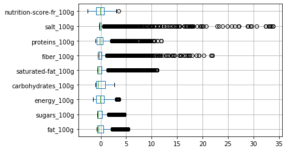

```python
# après normalisation
df_scaled.boxplot(vert=False)
plt.show()
```

## Methode de Tukey

sur les features numériques

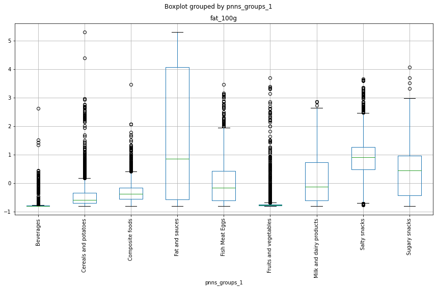

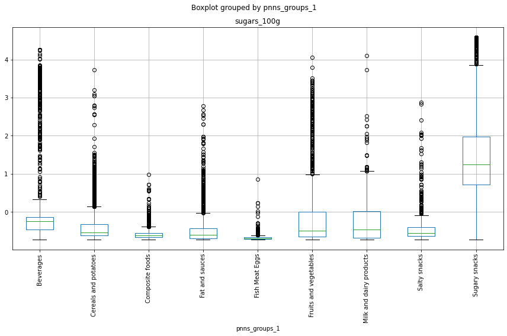

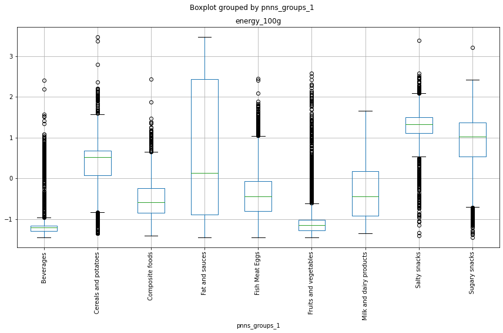

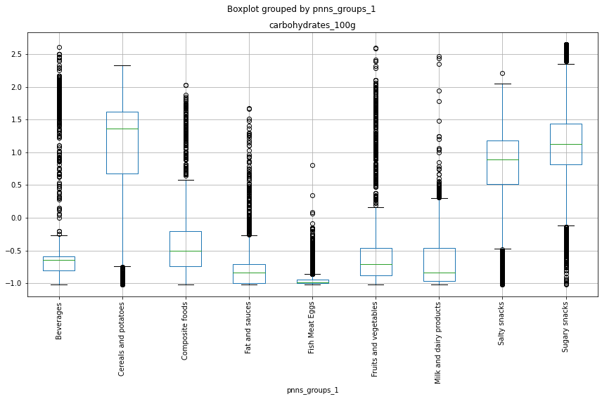

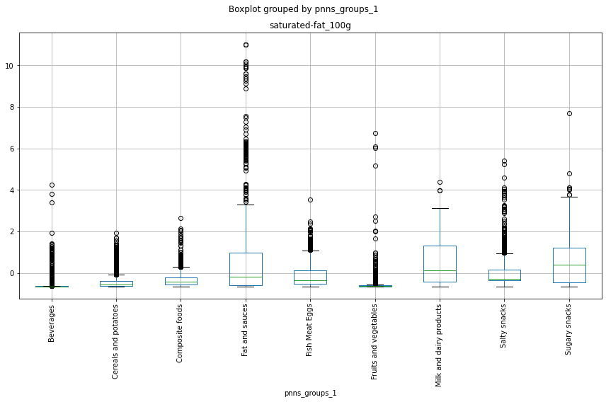

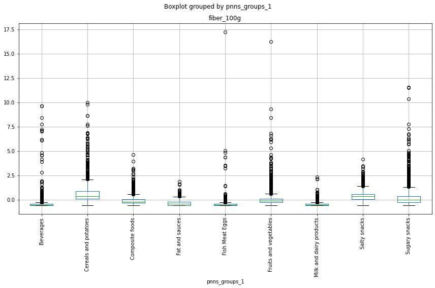

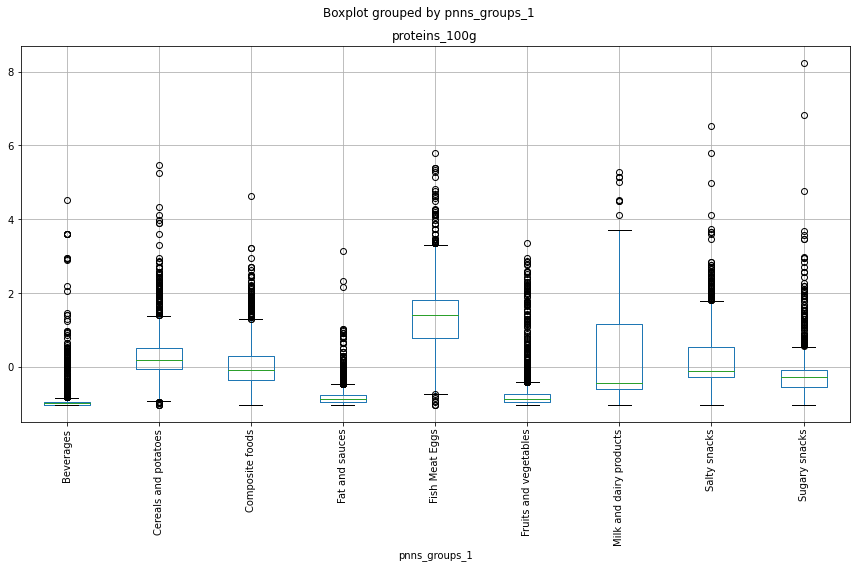

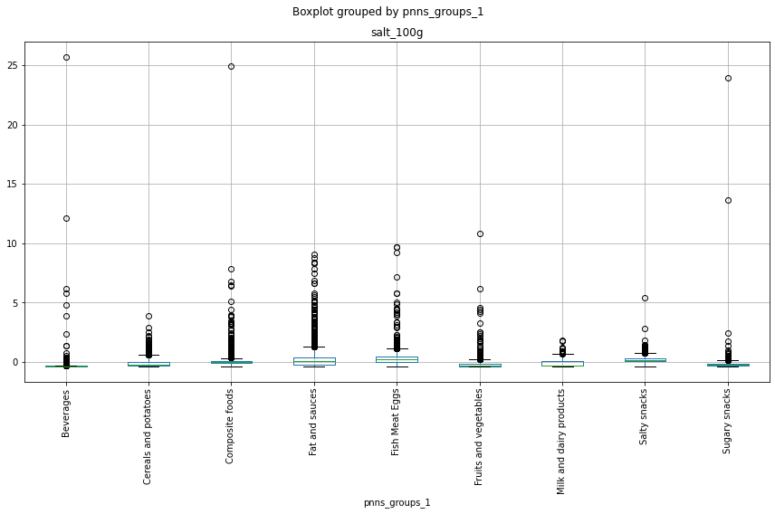

```python
#Create a boxplot
for col in numerical_value_100g:
    df_scaled.boxplot(col, by='pnns_groups_1', figsize=(12, 8))
    plt.xticks(rotation='90')
    plt.tight_layout()
    plt.show()
```